# Enfoque Estadistico del Aprendizaje - Trabajo Final - Regresion Bayesiana

# Inicialización

Fijamos la semilla para poder reproducir los experimentos. También se fija el numero de CPU’s a utilizar.

```r
set.seed(42)
options(mc.cores = 24)
```

# Librerias

Se importan las librerías a utilizar a lo largo de la notebook:

```r
# install.packages(pacman)
# install.packages("https://cran.r-project.org/src/contrib/rstan_2.21.2.tar.gz",repos = NULL,type="source")
# sudo apt-get install libglpk-dev
```

```r
library(pacman)
p_load(tidyverse, tidymodels, rsample, rstan, shinystan, rstanarm, devtools)
```

```r
source('../src/dataset.R')
source('../src/plot.R')
source('../src/model.R')
```

# Dataset y Analisis Exploratorio

Palmer Penguins

[Palmer Penguins](https://github.com/rfordatascience/tidytuesday/blob/master/data/2020/2020-07-28/readme.md)

## 1. Lectura del dataset

```r
dataset <- load_dataset() %>% mutate_if(is.character, as.factor)

dataset %>% glimpse()
```

```
## Rows: 344
## Columns: 8
## $ species           <fct> Adelie, Adelie, Adelie, Adelie, Adelie, Adelie, Adel~
## $ island            <fct> Torgersen, Torgersen, Torgersen, Torgersen, Torgerse~
## $ bill_length_mm    <dbl> 39.1, 39.5, 40.3, NA, 36.7, 39.3, 38.9, 39.2, 34.1, ~
## $ bill_depth_mm     <dbl> 18.7, 17.4, 18.0, NA, 19.3, 20.6, 17.8, 19.6, 18.1, ~
## $ flipper_length_mm <dbl> 181, 186, 195, NA, 193, 190, 181, 195, 193, 190, 186~
## $ body_mass_g       <dbl> 3750, 3800, 3250, NA, 3450, 3650, 3625, 4675, 3475, ~
## $ sex               <fct> male, female, female, NA, female, male, female, male~
## $ year              <dbl> 2007, 2007, 2007, 2007, 2007, 2007, 2007, 2007, 2007~
```

## 2. Variables

Se enumeran y describen breve-mente cada variable que forma parte del dataset:

Variables Numéricas:

- **bill_length_mm**: Longitud del pico del individuo medida en milímetros (también conocida como longitud del culmen).
- **bill_depth_mm**: Profundidad del pico del individuo medida en milímetros (también conocida como profundidad del culmen).
- **flipper_length_mm**: Longitud de la aleta del individuo medida en milímetros.
- **body_mass_g**: Masa corporal del individuo medida en gramos.
- **year**: Año en el que se registra el individuo.

Variables Categóricas:

- **species**: Especie del individuo (Adelie, Gentoo ;) o Chinstrap).
- **sex**: Sexo del individuo.
- **island**: Isla donde se encontré el individuo (Biscoe, Dream o Torgersen).

## 3. Resumen de faltantes

```r
missings_summary(dataset)
```

| Variable | Nª Categorias | Nª Faltantes | % Faltantes |
| --- | --- | --- | --- |
| sex | 3 | 11 | 3.20 |
| flipper_length_mm | 56 | 2 | 0.58 |
| bill_depth_mm | 81 | 2 | 0.58 |
| body_mass_g | 95 | 2 | 0.58 |
| bill_length_mm | 165 | 2 | 0.58 |
| island | 3 | 0 | 0.00 |
| species | 3 | 0 | 0.00 |
| year | 3 | 0 | 0.00 |

## 4. Varibles numericas

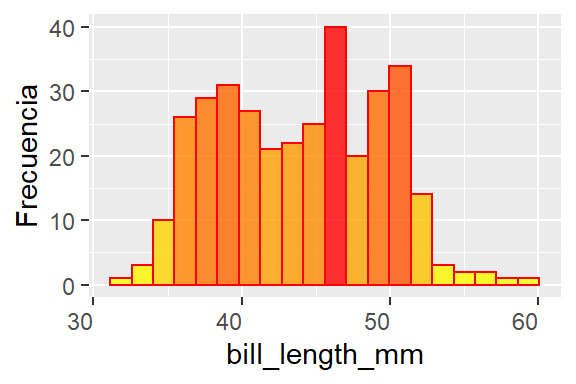

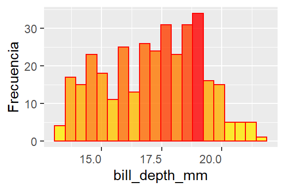

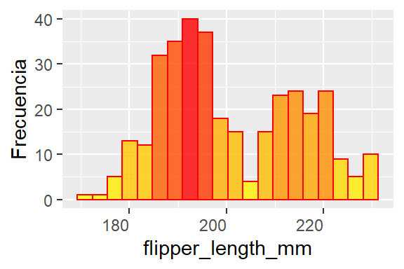

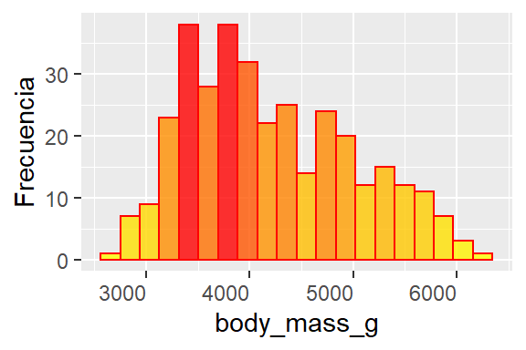

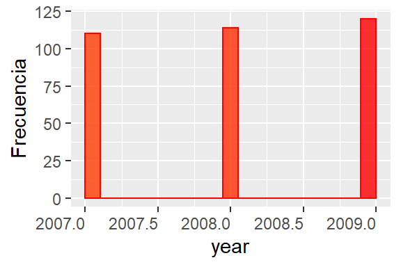

```r
hist_plots(dataset)
```

**Observaciones**

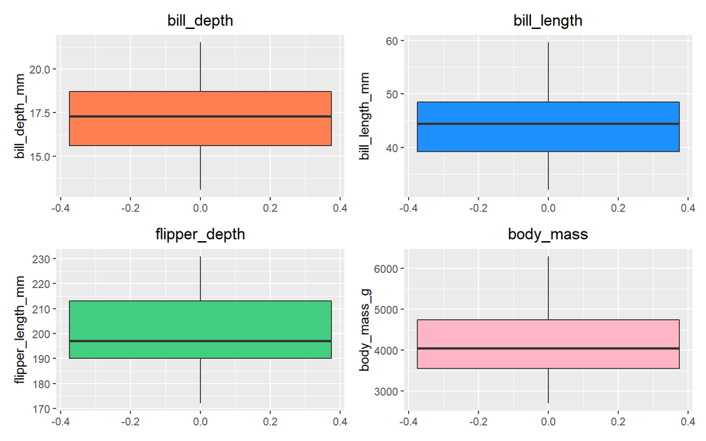

```r
library(patchwork)

p1<-ggplot(dataset, aes(y=bill_depth_mm)) +
  geom_boxplot(fill="coral") + ggtitle("bill_depth") + theme(plot.title = element_text(hjust = 0.5))

p2<-ggplot(dataset, aes(y=bill_length_mm)) +
  geom_boxplot(fill="dodgerblue") + ggtitle("bill_length") + theme(plot.title = element_text(hjust = 0.5))

p3<-ggplot(dataset, aes(y=flipper_length_mm)) +
  geom_boxplot(fill="seagreen3")+ ggtitle("flipper_depth") + theme(plot.title = element_text(hjust = 0.5))

p4<-ggplot(dataset, aes(y=body_mass_g)) +
  geom_boxplot(fill = "pink1") + ggtitle("body_mass") + theme(plot.title = element_text(hjust = 0.5))

p1 + p2 + p3 + p4
```

**Observaciones**

- No se observan outliers univariados

### Outliers

No se registran valores mas extremos que el mínimo y máximo valor en cada variables. Es decir que no encontramos outliers.

```r
outliers(dataset, column='bill_length_mm')
```

```
## $inf
## [1] 32.1
##
## $sup
## [1] 59.6
```

```r
outliers(dataset, column='bill_length_mm')
```

```
## $inf
## [1] 32.1
##
## $sup
## [1] 59.6
```

```r
outliers(dataset, column='bill_depth_mm')
```

```
## $inf
## [1] 13.1
##
## $sup
## [1] 21.5
```

```r
outliers(dataset, column='flipper_length_mm')
```

```
## $inf
## [1] 172
##
## $sup
## [1] 231
```

```r
outliers(dataset, column='body_mass_g')
```

```
## $inf
## [1] 2700
##
## $sup
## [1] 6300
```

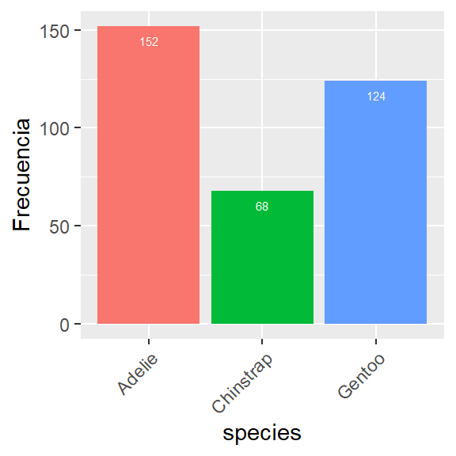

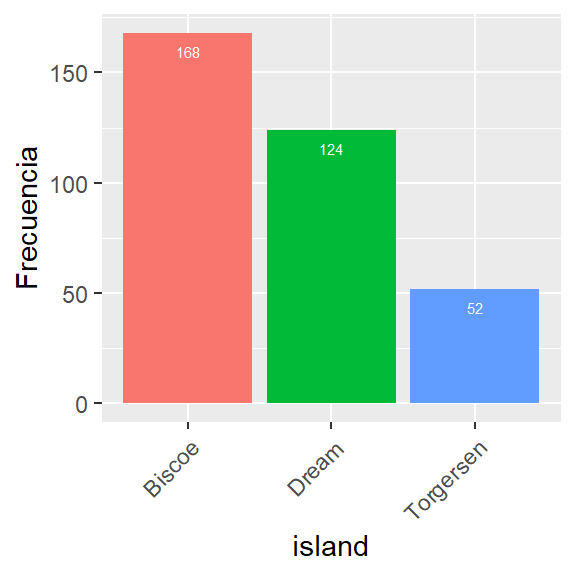

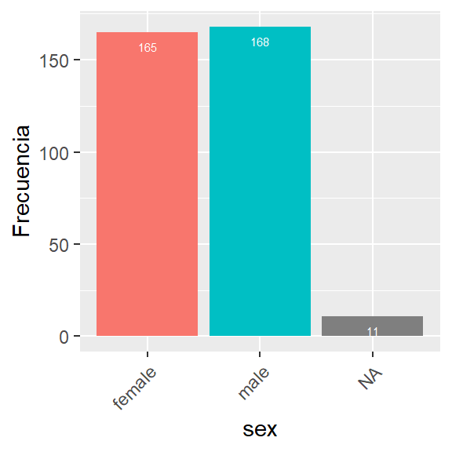

```r
bar_plots(dataset)
```

**Observaciones**

- La variable sexo se encuentra balanceada. Por otro lado, contiene algunos valores faltantes.
- La variable island esta completamente desbalanceada. Esto seguramente se debe a una diferencia en numero en las poblaciones en cada isla o a un sesgo al momento de registrar los individuos. Es decir que registramos con individuos en una isla que en otra.
- Lo mismo sucede con las especies de individuos. Vemos un gran desbalance entre la especie Chinstrap vs. otra especies. Por otro aldo Adelie y Gentoo tiene un conteo mas cercano

## 5. Excluir observaciones con missings

```r
dataset <- dataset %>% drop_na()
missings_summary(dataset)
```

| Variable | Nª Categorias | Nª Faltantes | % Faltantes |
| --- | --- | --- | --- |
| sex | 2 | 0 | 0 |
| island | 3 | 0 | 0 |
| species | 3 | 0 | 0 |
| year | 3 | 0 | 0 |
| flipper_length_mm | 54 | 0 | 0 |
| bill_depth_mm | 79 | 0 | 0 |
| body_mass_g | 93 | 0 | 0 |
| bill_length_mm | 163 | 0 | 0 |

## 6. Correlaciones

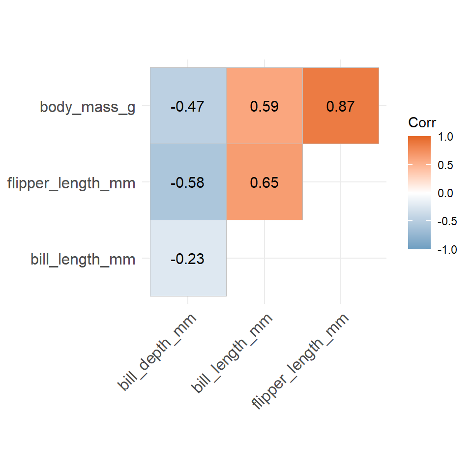

```r
corr_plot(dataset %>% dplyr::select(-year))
```

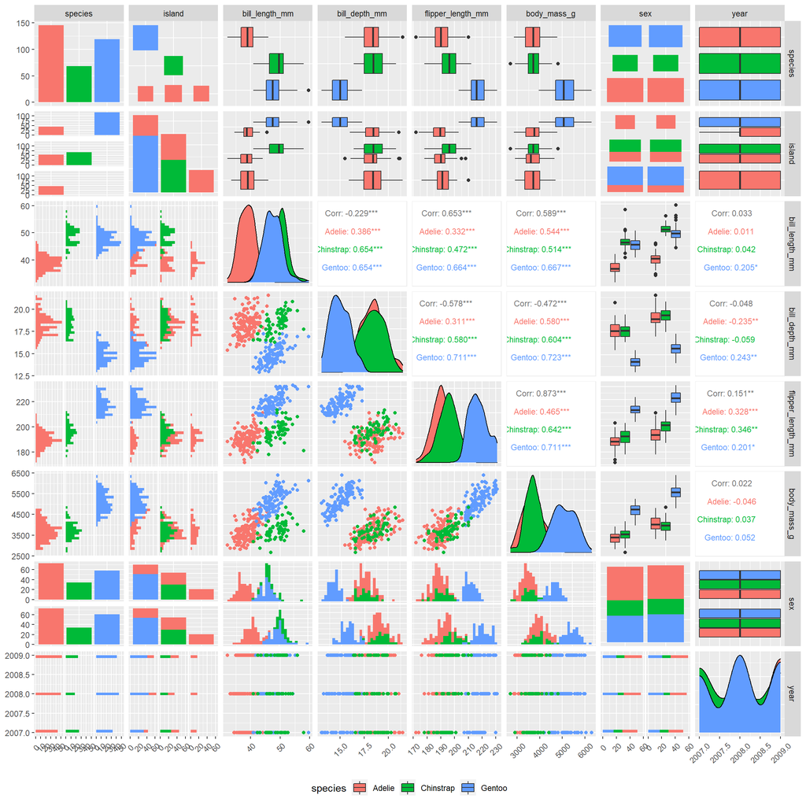

```r
segmented_pairs_plot(dataset, segment_column='species')
```

# Experimentos

## Experimento 1

- Solo variables numéricas.
- Regresión múltiple frecuentista.
- Regresión múltiple bayesiana con priors normales y exponencial.

### 1. Split train vs. test

```r
train_test <- train_test_split(dataset, train_size = 0.7, shuffle = TRUE)
```

```
## [1] "Train set size: 233"
## [1] "Test set size: 100"
```

```r
train_set <- train_test[[1]]
test_set  <- train_test[[2]]
```

### 2. Modelo lineal

```r
lineal_model_1 <- lm(
  body_mass_g ~ bill_length_mm + bill_depth_mm + flipper_length_mm,
  data = train_set
)

summary(lineal_model_1)
```

```
##
## Call:
## lm(formula = body_mass_g ~ bill_length_mm + bill_depth_mm + flipper_length_mm,
##     data = train_set)
##
## Residuals:
##     Min      1Q  Median      3Q     Max
## -868.52 -260.19  -17.83  239.28 1269.72
##
## Coefficients:
##                    Estimate Std. Error t value Pr(>|t|)
## (Intercept)       -6074.063    654.637  -9.279   <2e-16 ***
## bill_length_mm        3.530      6.297   0.561    0.576
## bill_depth_mm        12.534     16.232   0.772    0.441
## flipper_length_mm    49.318      2.874  17.157   <2e-16 ***
## ---
## Signif. codes:  0 '***' 0.001 '**' 0.01 '*' 0.05 '.' 0.1 ' ' 1
##
## Residual standard error: 382.4 on 229 degrees of freedom
## Multiple R-squared:  0.7755, Adjusted R-squared:  0.7725
## F-statistic: 263.6 on 3 and 229 DF,  p-value: < 2.2e-16
```

Quitamos los coeficientes que no son significativos para explicar a la variable **body_mass_g**:

```r
lineal_model_1 <- lm(body_mass_g ~ flipper_length_mm, data = train_set)

summary(lineal_model_1)
```

```
##
## Call:
## lm(formula = body_mass_g ~ flipper_length_mm, data = train_set)
##
## Residuals:
##     Min      1Q  Median      3Q     Max
## -857.93 -257.17  -17.05  232.95 1278.39
##
## Coefficients:
##                    Estimate Std. Error t value Pr(>|t|)
## (Intercept)       -5688.500    353.398  -16.10   <2e-16 ***
## flipper_length_mm    49.240      1.749   28.16   <2e-16 ***
## ---
## Signif. codes:  0 '***' 0.001 '**' 0.01 '*' 0.05 '.' 0.1 ' ' 1
##
## Residual standard error: 381.7 on 231 degrees of freedom
## Multiple R-squared:  0.7743, Adjusted R-squared:  0.7734
## F-statistic: 792.7 on 1 and 231 DF,  p-value: < 2.2e-16
```

### 3. Modelo bayesiano

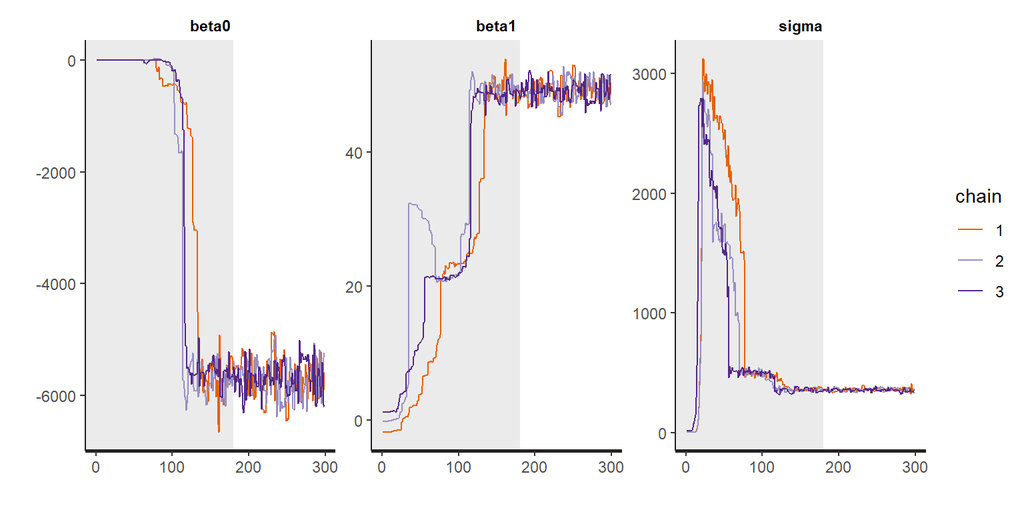

```r
bayesion_model_1 <- stan(
  model_code =  "
    data {
      int<lower=1>               obs_count;
      vector<lower=1>[obs_count] x;
      vector[obs_count]          y;
    }
    parameters {
      real          beta0;
      real          beta1;
      real<lower=0> sigma;
    }
    model {
      // Distribuciones a priori (Fijado por el investigador)
      beta0 ~ normal(0, 8000);  // Intercept
      beta1 ~ normal(0, 100);   // flipper_length_mm
      sigma ~ exponential(0.1); // Varianza

      // Likelihood
      y ~ normal(beta0 + beta1 * x, sigma);
    }
  ",
  data = list(
      obs_count = nrow(train_set),
      x         = colvalues(train_set, 'flipper_length_mm'),
      y         = colvalues(train_set, 'body_mass_g')
  ),
  chains = 3,
  iter   = 300,
  warmup = 180,
  thin   = 1
)

params_1 <- c('beta0', 'beta1', 'sigma')
traceplot(bayesion_model_1, pars = params_1, inc_warmup = TRUE)
```

### 4. Coeficientes

```r
lm_vs_br_coeficients(lineal_model_1, bayesion_model_1, params_1)
```

|  | Regresión Lineal | Regresión Bayesiana |
| --- | --- | --- |
| (Intercept) | -5688.49998 | -5685.56520 |
| flipper_length_mm | 49.23975 | 49.22755 |

### 4. Validación

```r
vars_1 <- c('flipper_length_mm')

lm_vs_br_models_validation(lineal_model_1, bayesion_model_1, params_1, vars_1, test_set)
```

| model | rmse | mae |
| --- | --- | --- |
| Lineal Regression | 419.7225 | 328.4396 |
| Bayesian Regression | 419.7401 | 328.5230 |

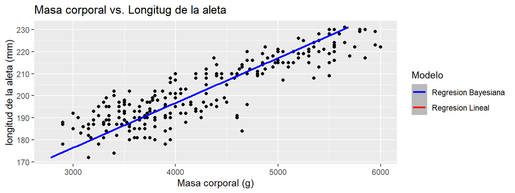

```r
bayesion_predictor_1 <- BayesianRegressionPredictor.from(bayesion_model_1, params_1, vars_1)

plot_compare_fit(
  lineal_model_1,
  bayesion_predictor_1,
  train_set,
  label_1 = 'Regresion Lineal',
  label_2 = 'Regresion Bayesiana'
)
```

## Experimento 2

- Idem a experimento 1, incorporando una variable categórica.
- Regresión múltiple frecuentista.
- Regresión bayesiana con priors normales y exponencial.

### 1. Modelo lineal

```r
lineal_model_2 <- lm(
    body_mass_g
      ~ bill_length_mm
      + bill_depth_mm
      + flipper_length_mm
      + sex,

  data = train_set
)

summary(lineal_model_2)
```

```
##
## Call:
## lm(formula = body_mass_g ~ bill_length_mm + bill_depth_mm + flipper_length_mm +
##     sex, data = train_set)
##
## Residuals:
##     Min      1Q  Median      3Q     Max
## -755.02 -255.89   -6.03  221.97  989.38
##
## Coefficients:
##                     Estimate Std. Error t value Pr(>|t|)
## (Intercept)       -1922.6152   729.5654  -2.635  0.00898 **
## bill_length_mm       -0.5331     5.4439  -0.098  0.92208
## bill_depth_mm       -92.9217    18.2692  -5.086 7.62e-07 ***
## flipper_length_mm    37.2016     2.8209  13.188  < 2e-16 ***
## sexmale             534.1583    59.5409   8.971  < 2e-16 ***
## ---
## Signif. codes:  0 '***' 0.001 '**' 0.01 '*' 0.05 '.' 0.1 ' ' 1
##
## Residual standard error: 329.5 on 228 degrees of freedom
## Multiple R-squared:  0.834,  Adjusted R-squared:  0.8311
## F-statistic: 286.5 on 4 and 228 DF,  p-value: < 2.2e-16
```

Quitamos los coeficientes que no son significativos para explicar a la variable **body_mass_g**:

```r
lineal_model_2 <- lm(
    body_mass_g
      ~ bill_depth_mm
      + flipper_length_mm
      + sex,
  data = train_set
)

summary(lineal_model_2)
```

```
##
## Call:
## lm(formula = body_mass_g ~ bill_depth_mm + flipper_length_mm +
##     sex, data = train_set)
##
## Residuals:
##     Min      1Q  Median      3Q     Max
## -758.30 -258.55   -5.04  223.02  989.59
##
## Coefficients:
##                    Estimate Std. Error t value Pr(>|t|)
## (Intercept)       -1912.697    720.936  -2.653  0.00853 **
## bill_depth_mm       -93.106     18.133  -5.135 6.04e-07 ***
## flipper_length_mm    37.053      2.373  15.617  < 2e-16 ***
## sexmale             533.673     59.206   9.014  < 2e-16 ***
## ---
## Signif. codes:  0 '***' 0.001 '**' 0.01 '*' 0.05 '.' 0.1 ' ' 1
##
## Residual standard error: 328.7 on 229 degrees of freedom
## Multiple R-squared:  0.834,  Adjusted R-squared:  0.8319
## F-statistic: 383.6 on 3 and 229 DF,  p-value: < 2.2e-16
```

### 2. Modelo bayesiano

Construimos una matriz con todas las variables(X) mas el intercept:

```r
to_model_input <- function(df) {
  model.matrix(
    body_mass_g
      ~ bill_depth_mm
      + flipper_length_mm
      + sex,
    data = df
  )
}

train_X <- train_set %>% to_model_input()
test_X  <- test_set %>% to_model_input()

head(train_X)
```

```
##   (Intercept) bill_depth_mm flipper_length_mm sexmale
## 1           1          18.8               197       1
## 2           1          14.6               211       0
## 3           1          19.1               195       1
## 4           1          15.9               224       1
## 5           1          18.5               201       1
## 6           1          18.3               195       1
```

Definimos y corremos el modelo bayesiano:

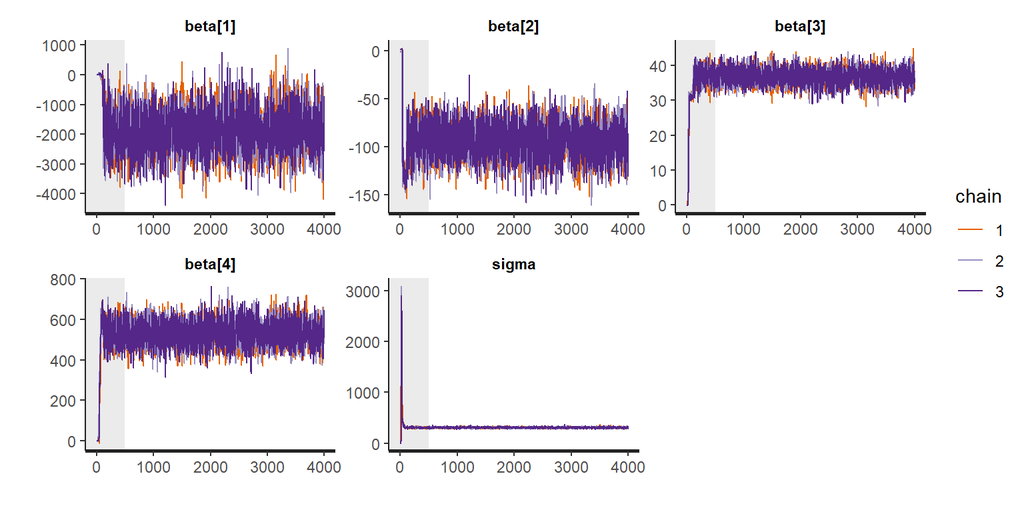

```r
bayesion_model_2 <- stan(
  model_code = "
    data {
      int<lower=1>                 obs_count;
      int<lower=1>                 coef_count;
      matrix[obs_count,coef_count] X;
      vector[obs_count]            y;
    }
    parameters {
      vector[coef_count]  beta;
      real<lower=0>       sigma;
    }
    model {
      // Distribuciones a priori
      beta[1] ~ normal(0, 3000); // Intecept = beta0 + sexfemale
      beta[2] ~ normal(0, 200);  // bill_depth_mm
      beta[3] ~ normal(0, 200);  // flipper_length_mm
      beta[4] ~ normal(0, 600);  // sexmale

      sigma ~ exponential(0.1);  // Varianza

      // Likelihood
      y ~ normal(X * beta, sigma);
    }
  ",
  data = list(
      obs_count  = dim(train_X)[1],
      coef_count = dim(train_X)[2],
      y          = colvalues(train_set, 'body_mass_g'),
      X          = train_X
  ),
  chains = 3,
  iter   = 4000,
  warmup = 500,
  thin   = 1
)

params_2 <- c('beta[1]', 'beta[2]', 'beta[3]', 'beta[4]', 'sigma')
traceplot(bayesion_model_2, inc_warmup = TRUE, pars = params_2)
```

### 3. Coeficientes

```r
lineal_model_2$coefficients
```

```
##       (Intercept)     bill_depth_mm flipper_length_mm           sexmale
##       -1912.69656         -93.10594          37.05300         533.67323
```

```r
br_coeficients(bayesion_model_2, params_2)
```

| Coeficiente | Valor |
| --- | --- |
| beta[1] | -1862.89151 |
| beta[2] | -93.99942 |
| beta[3] | 36.88142 |
| beta[4] | 533.81910 |
| sigma | 310.18094 |

### 4. Validación

```r
vars_2 <- c('bill_depth_mm', 'flipper_length_mm', 'sexmale')

lm_vs_br_models_validation(
  lineal_model_2,
  bayesion_model_2,
  params_2,
  vars_2,
  test_set,
  as.data.frame(test_X)
)
```

| model | rmse | mae |
| --- | --- | --- |
| Lineal Regression | 366.7986 | 301.1338 |
| Bayesian Regression | 367.0612 | 301.2592 |

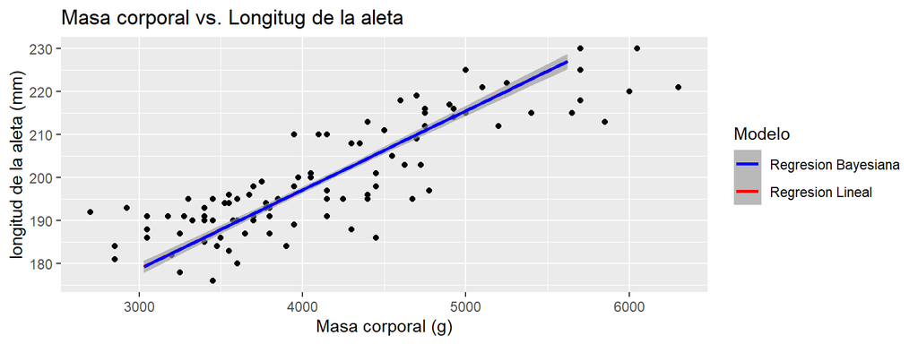

```r
bayesion_predictor_2 <- BayesianRegressionPredictor.from(bayesion_model_2, params_2, vars_2)

plot_compare_fit(
  lineal_model_2,
  bayesion_predictor_2,
  test_set,
  as.data.frame(test_X),
  label_1 = 'Regresion Lineal',
  label_2 = 'Regresion Bayesiana'
)
```

## Experimento 3

- Idem a experimento 1 incorporando outliers en alguna variable numérica.
- Regresión múltiple frecuentista.
- Regresión bayesiana con priors normales y exponencial.

### 1. Outliers

A continuación vamos a agregar outliers a la variable **flipper_length_mm**, la cual define la longitud de la aleta del individuo medida en milímetros.

Para visualizar los nuevos outliers a continuación graficamos **flipper_length_mm** vs. **body_mass_g** antes y después de agregar outliers:

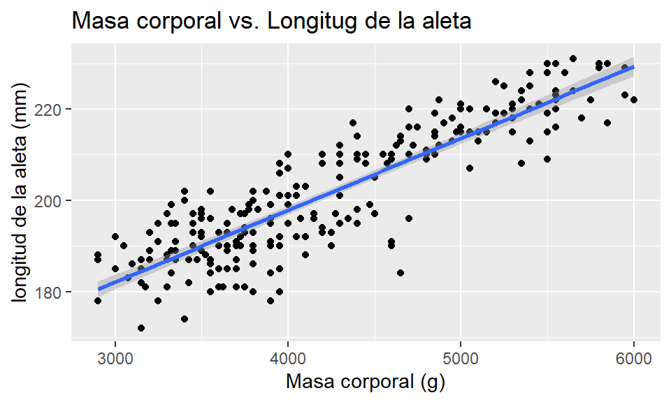

```r
plot_data(train_set)
```

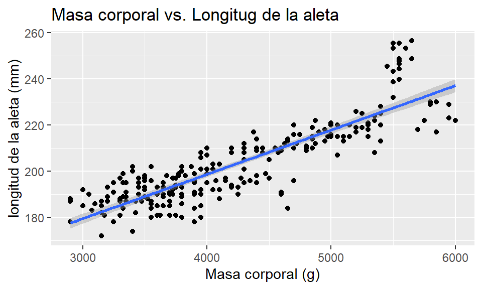

```r
train_set_with_outliers <- train_set %>%
  mutate(flipper_length_mm = ifelse(
    body_mass_g > 5400 & body_mass_g < 5700,
    flipper_length_mm + (flipper_length_mm * runif(1, 0.1, 0.2)),
    flipper_length_mm
  ))

plot_data(train_set_with_outliers)
```

### 2. Modelo lineal

```r
lineal_model_3 <- lm(
  body_mass_g ~ flipper_length_mm,
  data = train_set_with_outliers
)
summary(lineal_model_3)
```

```
##
## Call:
## lm(formula = body_mass_g ~ flipper_length_mm, data = train_set_with_outliers)
##
## Residuals:
##     Min      1Q  Median      3Q     Max
## -799.37 -298.36   -5.72  282.48 1161.29
##
## Coefficients:
##                    Estimate Std. Error t value Pr(>|t|)
## (Intercept)       -3656.483    304.802  -12.00   <2e-16 ***
## flipper_length_mm    38.833      1.494   25.99   <2e-16 ***
## ---
## Signif. codes:  0 '***' 0.001 '**' 0.01 '*' 0.05 '.' 0.1 ' ' 1
##
## Residual standard error: 405.5 on 231 degrees of freedom
## Multiple R-squared:  0.7452, Adjusted R-squared:  0.7441
## F-statistic: 675.7 on 1 and 231 DF,  p-value: < 2.2e-16
```

Comparemos el ajuste del modelo lineal ajustando en un dataset de train con y sin outliers:

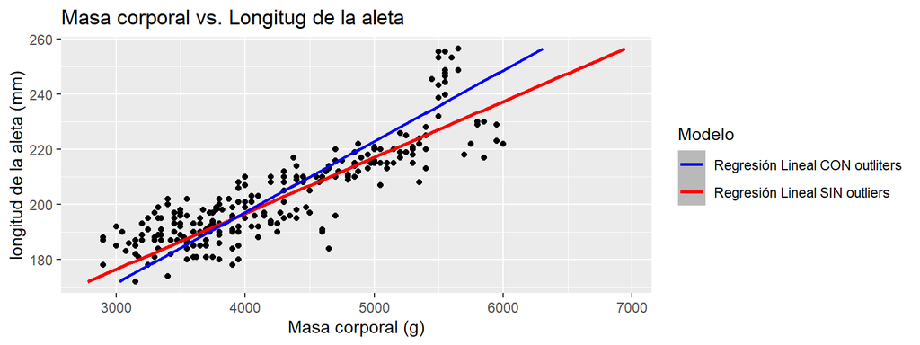

```r
plot_compare_fit(
  lineal_model_1,
  lineal_model_3,
  train_set_with_outliers,
  label_1='Regresión Lineal SIN outliers',
  label_2='Regresión Lineal CON outliters'
)
```

Se aprecia que el modelo entrenado en **train_set_outliers** esta apalancado por las observaciones atípicas

### 2. Modelo lineal Robusto

Entrenamos una regresión lineal múltiple robusta para intentar de disminuir el efecto de los nuevos outliers:

```r
robust_lineal_model_3 <- rlm(
  body_mass_g ~ flipper_length_mm,
  data = train_set_with_outliers
)
```

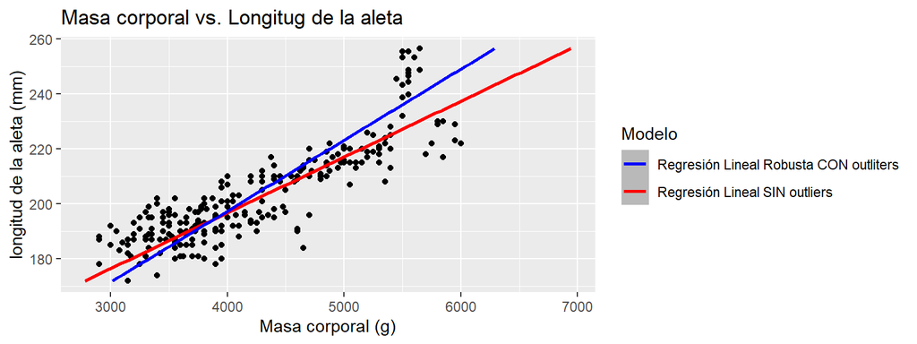

```r
plot_compare_fit(
  lineal_model_1,
  robust_lineal_model_3,
  train_set_with_outliers,
  label_1='Regresión Lineal SIN outliers',
  label_2='Regresión Lineal Robusta CON outliters'
)
```

```r
lm_vs_lm_models_validation(lineal_model_3, robust_lineal_model_3, train_set_with_outliers)
```

| model | rmse | mae |
| --- | --- | --- |
| Modelo B | 1025.711 | 816.6682 |
| Modelo A | 1028.506 | 819.5311 |

```r
lm_vs_lm_models_validation(lineal_model_3, robust_lineal_model_3, test_set)
```

| model | rmse | mae |
| --- | --- | --- |
| Modelo B | 459.2681 | 353.7947 |
| Modelo A | 457.5500 | 353.9761 |

### 3. Modelo bayesiano con Likelihood normal

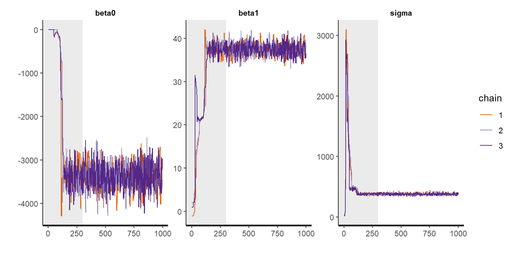

```r
bayesion_model_3 <- stan(
  model_code =  "
    data {
      int<lower=1>               obs_count;
      vector<lower=1>[obs_count] x;
      vector[obs_count]          y;
    }
    parameters {
      real          beta0;
      real          beta1;
      real<lower=0> sigma;
    }
    model {
      // Distribuciones a priori (Fijado por el investigador)
      beta0 ~ normal(0, 1000);  // Intercept
      beta1 ~ normal(0, 100);   // flipper_length_mm
      sigma ~ exponential(0.1); // Varianza

      // Likelihood
      y ~ normal(beta0 + beta1 * x, sigma);
    }
  ",
  data = list(
      obs_count = nrow(train_set_with_outliers),
      x = colvalues(train_set_with_outliers, 'flipper_length_mm'),
      y = colvalues(train_set_with_outliers, 'body_mass_g')
  ),
  chains = 3,
  iter   = 1000,
  warmup = 300,
  thin   = 1
)

params_3 <- c('beta0', 'beta1', 'sigma')
traceplot(bayesion_model_3, pars = params_3, inc_warmup = TRUE)
```

### 4. Coeficientes

```r
lm_vs_br_coeficients(robust_lineal_model_3, bayesion_model_3, params_3)
```

|  | Regresión Lineal | Regresión Bayesiana |
| --- | --- | --- |
| (Intercept) | -3641.06583 | -3378.53011 |
| flipper_length_mm | 38.70668 | 37.47339 |

### 5. Validación

```r
vars_3 <- c('flipper_length_mm')

lm_vs_br_models_validation(robust_lineal_model_3, bayesion_model_3, params_3, vars_3, test_set)
```

| model | rmse | mae |
| --- | --- | --- |
| Lineal Regression | 459.2681 | 353.7947 |
| Bayesian Regression | 464.3637 | 360.6631 |

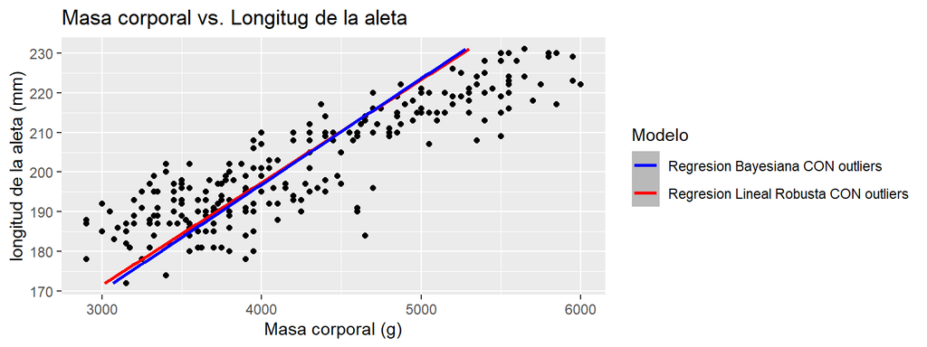

```r
bayesion_predictor_3 <- BayesianRegressionPredictor.from(bayesion_model_3, params_3, vars_3)

plot_compare_fit(
  robust_lineal_model_3,
  bayesion_predictor_3,
  train_set,
  label_1='Regresion Lineal Robusta CON outliers',
  label_2='Regresion Bayesiana CON outliers'
)
```

### 6. Modelo bayesiano con Likelihood t-student

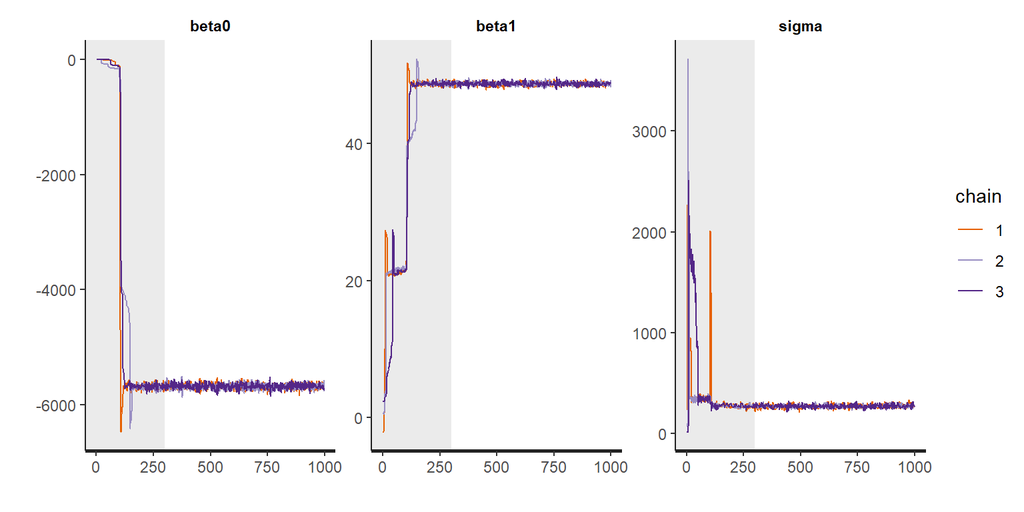

```r
bayesion_model_3.1 <- stan(
  model_code =  "
    data {
      int<lower=1>               obs_count;
      vector<lower=1>[obs_count] x;
      vector[obs_count]          y;
    }
    parameters {
      real          beta0;
      real          beta1;
      real<lower=0> sigma;
    }
    model {
      // Distribuciones a priori (Fijado por el investigador)
      beta0 ~ normal(-5700, 50);  // Intercept (Muy informativa!!!)
      beta1 ~ normal(49, 20);      // flipper_length_mm (Muy informativa!!!)
      sigma ~ exponential(0.1); // Varianza

      // Likelihood
      y ~ student_t(2, beta0 + beta1 * x, sigma);
    }
  ",
  data = list(
      obs_count = nrow(train_set_with_outliers),
      x = colvalues(train_set_with_outliers, 'flipper_length_mm'),
      y = colvalues(train_set_with_outliers, 'body_mass_g')
  ),
  chains = 3,
  iter   = 1000,
  warmup = 300,
  thin   = 1
)

params_3 <- c('beta0', 'beta1', 'sigma')
traceplot(bayesion_model_3.1, pars = params_3, inc_warmup = TRUE)
```

### 7. Coeficientes

```r
lm_vs_br_coeficients(lineal_model_1, bayesion_model_3.1, params_3)
```

|  | Regresión Lineal | Regresión Bayesiana |
| --- | --- | --- |
| (Intercept) | -5688.49998 | -5673.59427 |
| flipper_length_mm | 49.23975 | 48.78125 |

### 8. Validación

```r
vars_3 <- c('flipper_length_mm')

lm_vs_br_models_validation(lineal_model_1, bayesion_model_3.1, params_3, vars_3, test_set)
```

| model | rmse | mae |
| --- | --- | --- |
| Lineal Regression | 419.7225 | 328.4396 |
| Bayesian Regression | 427.3341 | 330.3013 |

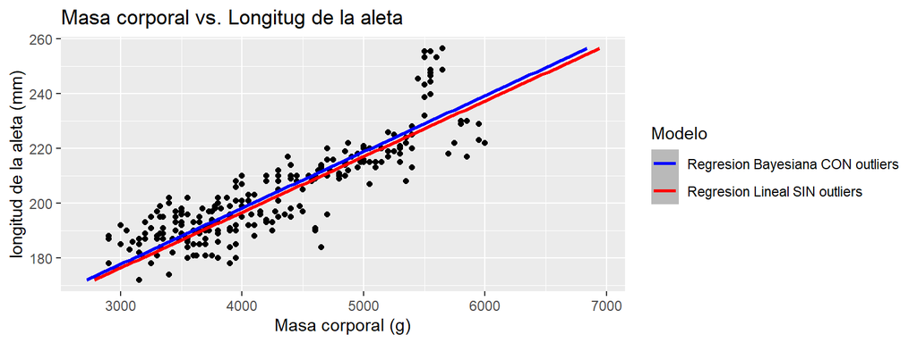

```r
bayesion_predictor_3.1 <- BayesianRegressionPredictor.from(bayesion_model_3.1, params_3, vars_3)

plot_compare_fit(
  lineal_model_1,
  bayesion_predictor_3.1,
  train_set_with_outliers,
  label_1='Regresion Lineal SIN outliers',
  label_2='Regresion Bayesiana CON outliers'
)
```

## Experimento 4

- Idem experimento 1 pero reduciendo la cantidad de observaciones a pocos valores (ej:30).
- Regresión múltiple frecuentista.
- Regresión bayesiana con priors normales y exponencial.

### 1. Split train - test

```r
train_test <- train_test_split(dataset, train_size = 0.05, shuffle = TRUE)
```

```
## [1] "Train set size: 16"
## [1] "Test set size: 317"
```

```r
train_set_4 <- train_test[[1]]
test_set_4  <- train_test[[2]]
```

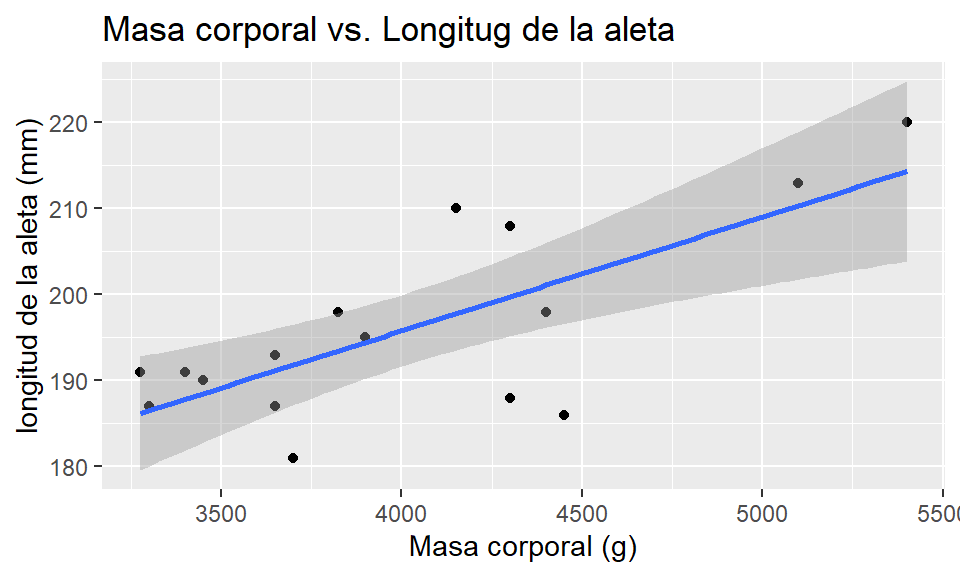

```r
plot_data(train_set_4)
```

### 2. Modelo lineal

```r
lineal_model_4 <- lm(
  body_mass_g ~ flipper_length_mm,
  data = train_set_4
)
```

### 3. Modelo bayesiano

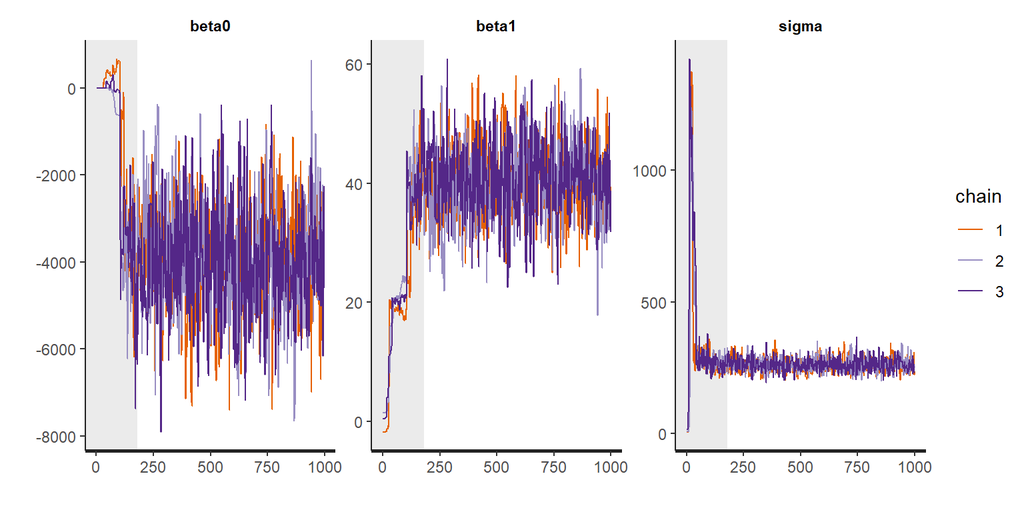

```r
bayesion_model_4 <- stan(
  model_code =  "
    data {
      int<lower=1>               obs_count;
      vector<lower=1>[obs_count] x;
      vector[obs_count]          y;
    }
    parameters {
      real          beta0;
      real          beta1;
      real<lower=0> sigma;
    }
    model {
      // Distribuciones a priori
      beta0 ~ normal(0, 8000); // Intercept
      beta1 ~ normal(0, 100);
      sigma ~ exponential(0.1);

      // Likelihood
      y ~ normal(beta0 + beta1 * x, sigma);
    }
  ",
  data = list(
      obs_count = nrow(train_set_4),
      x = colvalues(train_set_4, 'flipper_length_mm'),
      y  = colvalues(train_set_4, 'body_mass_g')
  ),
  chains = 3,
  iter   = 1000,
  warmup = 180,
  thin   = 1
)

params_4 <- c('beta0', 'beta1', 'sigma')
traceplot(bayesion_model_4, pars = params_4, inc_warmup = TRUE)
```

### 4. Coeficientes

Coeficientes de la regresión múltiple:

```r
lineal_model_4$coefficients
```

```
##       (Intercept) flipper_length_mm
##       -4053.56855          41.16935
```

Coeficientes descubiertos por la regresión múltiple bayesiana:

```r
for(param in params_4) print(get_posterior_mean(bayesion_model_4, par=param)[4])
```

```
## [1] -3924.577
## [1] 40.50081
## [1] 262.5933
```

### 5. Validación

```r
vars_4 <- c('flipper_length_mm')

lm_vs_br_models_validation(lineal_model_4, bayesion_model_4, params_4, vars_4, test_set)
```

| model | rmse | mae |
| --- | --- | --- |
| Lineal Regression | 444.5798 | 351.8746 |
| Bayesian Regression | 447.4354 | 353.9687 |

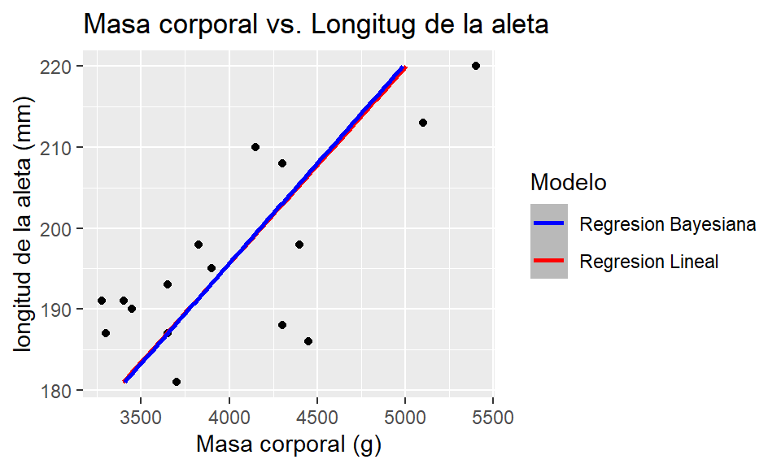

```r
bayesion_predictor_4 <- BayesianRegressionPredictor.from(bayesion_model_4, params_4, vars_4)

plot_compare_fit(
  lineal_model_4,
  bayesion_predictor_4,
  train_set_4,
  label_1='Regresion Lineal',
  label_2='Regresion Bayesiana'
)
```

## Experimento 5

- Igual al experimento 1 pero proponiendo dos nuevas regresiones bayesianas con priors para los parámetros que sean:
  - Una poca informativa (uniforme).
  - Una muy informativa (sesgada o con muy poca varianza).
- Comparar con resultados de la bayesiana del experimento A

### 1. Modelo bayesiano con parametro con distribucion poco informativa

#### 1. Modelo

Definimos una [distribución uniforme](https://mc-stan.org/docs/2_21/functions-reference/uniform-distribution.html) para el beta asociado a la variable **flipper_length_mm** y el intercepto

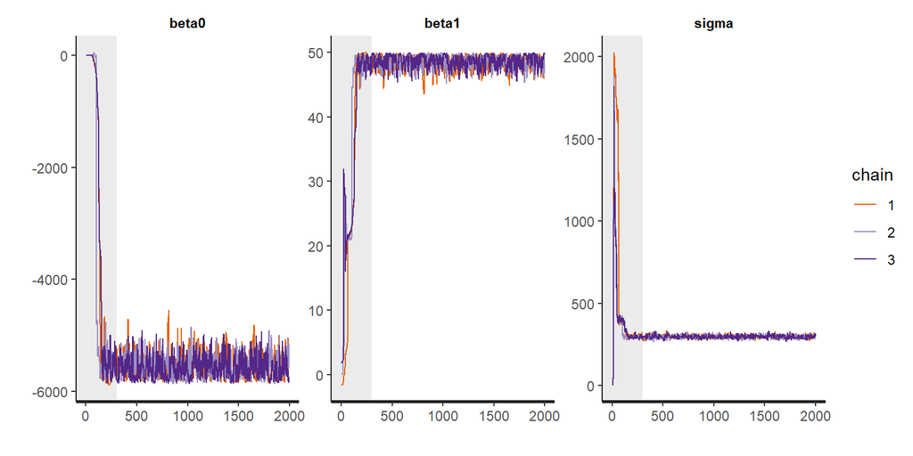

```r
bayesion_model_5a <- stan(
  model_code =  "
    data {
      int<lower=1>               obs_count;
      vector<lower=1>[obs_count] x;
      vector[obs_count]          y;
    }
    parameters {
      real          beta0;
      real          beta1;
      real<lower=0> sigma;
    }
    model {
      // Distribuciones a priori
      beta0 ~ uniform(-6000, 2000); // Intercept
      beta1 ~ uniform(-50, 50);
      sigma ~ exponential(0.5);

      // Likelihood
      y ~ normal(beta0 + beta1 * x, sigma);
    }
  ",
  data = list(
      obs_count = nrow(train_set),
      x = colvalues(train_set, 'flipper_length_mm'),
      y  = colvalues(train_set, 'body_mass_g')
  ),
  chains = 3,
  iter   = 2000,
  warmup = 300,
  thin   = 1
)

params_5a <- c('beta0', 'beta1', 'sigma')
traceplot(bayesion_model_5a, pars = params_5a, inc_warmup = TRUE)
```

#### 2. Coeficientes

```r
br_vs_br_coeficients(bayesion_model_1, bayesion_model_5a, params_5a)
```

| Coeficiente | Modelo.A | Modelo.B |
| --- | --- | --- |
| beta0 | -5685.56520 | -5556.53516 |
| beta1 | 49.22755 | 48.58603 |
| sigma | 356.55331 | 297.76297 |

#### 3. Validacion

```r
vars_5a <- c('flipper_length_mm')

lm_vs_br_models_validation(lineal_model_1, bayesion_model_5a, params_5a, vars_5a, test_set)
```

| model | rmse | mae |
| --- | --- | --- |
| Lineal Regression | 419.7225 | 328.4396 |
| Bayesian Regression | 420.7400 | 329.6077 |

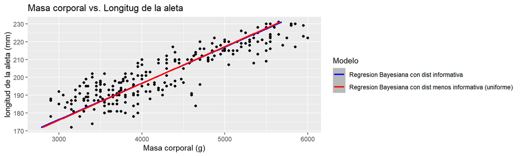

```r
bayesion_predictor_5a <- BayesianRegressionPredictor.from(bayesion_model_5a, params_5a, vars_5a)

plot_compare_fit(
  bayesion_predictor_1,
  bayesion_predictor_5a,
  train_set,
  label_1='Regresion Bayesiana con dist informativa',
  label_2='Regresion Bayesiana con dist menos informativa (uniforme)'
)
```

### 2. Modelo bayesiano con parametro con distribucion muy informativa

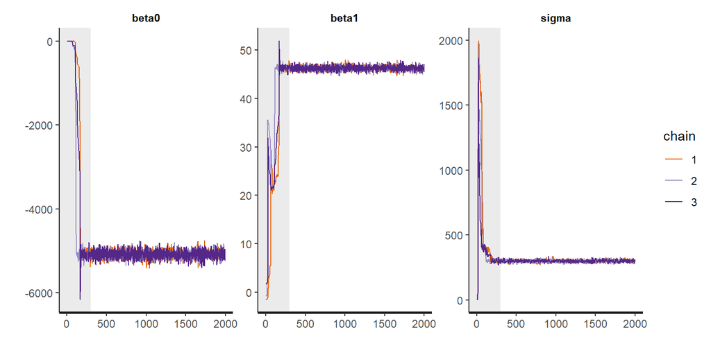

```r
bayesion_model_5b <- stan(
  model_code =  "
    data {
      int<lower=1>               obs_count;
      vector<lower=1>[obs_count] x;
      vector[obs_count]          y;
    }
    parameters {
      real          beta0;
      real          beta1;
      real<lower=0> sigma;
    }
    model {
      // Distribuciones a priori
      beta0 ~ normal(-5000, 100); // Intercept
      beta1 ~ normal(50, 5);
      sigma ~ exponential(0.5);

      // Likelihood
      y ~ normal(beta0 + beta1 * x, sigma);
    }
  ",
  data = list(
      obs_count = nrow(train_set),
      x = colvalues(train_set, 'flipper_length_mm'),
      y  = colvalues(train_set, 'body_mass_g')
  ),
  chains = 3,
  iter   = 2000,
  warmup = 300,
  thin   = 1
)

params_5b <- c('beta0', 'beta1', 'sigma')
traceplot(bayesion_model_5b, pars = params_5b, inc_warmup = TRUE)
```

#### 2. Coeficientes

```r
br_vs_br_coeficients(bayesion_model_5a, bayesion_model_5b,params_5a)
```

| Coeficiente | Modelo.A | Modelo.B |
| --- | --- | --- |
| beta0 | -5556.53516 | -5082.68747 |
| beta1 | 48.58603 | 46.25031 |
| sigma | 297.76297 | 299.36087 |

#### 3. Validacion

```r
vars_5b <- c('flipper_length_mm')

lm_vs_br_models_validation(lineal_model_1, bayesion_model_5b, params_5b, vars_5b, test_set)
```

| model | rmse | mae |
| --- | --- | --- |
| Lineal Regression | 419.7225 | 328.4396 |
| Bayesian Regression | 425.8653 | 334.9093 |

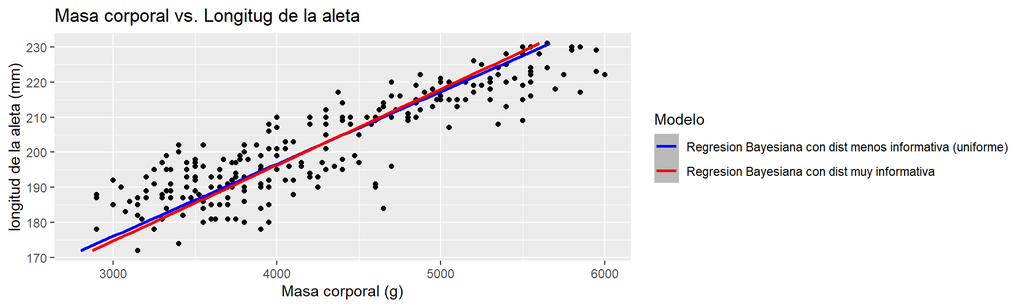

```r
bayesion_predictor_5a <- BayesianRegressionPredictor.from(bayesion_model_5a, params_5a, vars_5a)
bayesion_predictor_5b <- BayesianRegressionPredictor.from(bayesion_model_5b, params_5b, vars_5b)

plot_compare_fit(
  bayesion_predictor_5a,
  bayesion_predictor_5b,
  train_set,
  label_1='Regresion Bayesiana con dist menos informativa (uniforme)',
  label_2='Regresion Bayesiana con dist muy informativa'
)
```

## Referencias

- [Making Predictions from Stan models in R](https://medium.com/@alex.pavlakis/making-predictions-from-stan-models-in-r-3e349dfac1ed)
- [How to represent a categorical predictor rstan?](https://stackoverflow.com/questions/29183577/how-to-represent-a-categorical-predictor-rstan)